# Exploratory Data Analysis - Basic Syntax and practical Application

Frank Fichtenmueller

## Principle of Analytic Graphics

- **Principle 1: Show Comparisons**
  - always comparative (compared to what)
  - randomized trial - compare control group to test group
  - evidence for a hypothesis is always relative to another competing hypothesis
- **Principle 2: Show causality/mechanism/explanation/systematic structure**
  - form hypothesis to evidence showing a relationship (causal framework, why something happened)
- **Principle 3: Show multivariate data**
  - more than 2 variables because the real world is multivariate
  - show as much data on a plot as you can
  - *example*
- slightly negative relationship between pollution and mortality
  - when split up by season, the relationships are all positive $\rightarrow$ season = confounding variable
- **Principle 4: Integration of evidence**
  - use as many modes of evidence/displaying evidence as possible (modes of data presentation)
  - integrate words/numbers/images/diagrams (information rich)
  - analysis should drive the tool
- **Principle 5: Describe/document evidence with appropriate labels/scales/sources**
  - add credibility to that data graphic
- **Principle 6: Content is the most important**
  - analytical presentations ultimately stand/fall depending on quality/relevance/integrity of content

## Exploratory Graphs ([examples](http://gallery.r-enthusiasts.com/))

- **Purpose**: understand data properties, find pattern in data, suggest modeling strategies, debug
- **Characteristics**: made quickly, large number produced, gain personal understanding, appearances and presentation are arenât as important

### One Dimension Summary of Data

- `summary(data)` = returns min, 1st quartile, median, mean, 3rd quartile, max
- `boxplot(data, col = âblueâ)` = produces a box with middles 50% highlighted in the specified color
  - `whiskers` = $\pm 1.58IQR/\sqrt{n}$
    - IQR = interquartile range, Q$_3$ - Q$_1$
  - `box` = 25%, median, 75%
- `histograms(data, col = âgreenâ)` = produces a histogram with specified breaks and color
  - `breaks = 100` = the higher the number is the smaller/narrower the histogram columns are
- `rug(data)` = density plot, add a strip under the histogram indicating location of each data point
- `barplot(data, col = wheat)` = produces a bar graph, usually for categorical data
- **Overlaying Features**
- `abline(h/v = 12)` = overlays horizontal/vertical line at specified location
  - `col = âredâ` = specifies color
  - `lwd = 4` = line width
  - `lty = 2` = line type

### Two Dimensional Summaries

- multiple/overlay 1D plots (using lattice/ggplot2)
- **box plots**: `boxplot(pm25 ~ region, data = pollution, col = âredâ)`
- **histogram**:
  - `par(mfrow = c(2, 1), mar = c(4, 4, 2, 1))` = set margin
  - `hist(subset(pollution, region == "east")$pm25, col = "green")` = first histogram
  - `hist(subset(pollution, region == "west")$pm25, col = "green")` = second histogram
- **scatterplot**
  - `with(pollution, plot(latitude, pm25, col = region))`
  - `abline(h = 12, lwd = 2, lty = 2)` = plots horizontal dotted line
  - `plot(jitter(child, 4)~parent, galton)` = spreads out data points at the same position to simulate measurement error/make high frequency more visibble

[output not shown]

- **multiple scatter plots**
  - `par(mfrow = c(1, 2), mar = c(5, 4, 2, 1))` = sets margins
  - `with(subset(pollution, region == "west"), plot(latitude, pm25, main = "West"))` = left scatterplot
  - `with(subset(pollution, region == "east"), plot(latitude, pm25, main = "East"))` = right scatterplot

### Process of Making a Plot/Considerations

- where will plot be made? screen or file?
- how will plot be used? viewing on screen/web browser/print/presentation?
- large amount of data vs few points?
- need to be able to dynamically resize?
- **plotting system**: base, lattice, ggplot2?

## Base Plotting

- blank canvas, âartistâs paletteâ, start with plot function
- annotations - text, lines, points, axis
- convenient, but cannot go back when started (need to plan ahead)
- everything need to be manually set carefully to be able to achieve the desired effect (margins)
- core plotting/graphics engine in R encapsulated in the following
  - *graphics*: plotting functions for vase graphing system (plot, hist, boxplot, text)
  - *grDevices*: contains all the code implementing the various graphics devices (x11, PDF, PostScript, PNG, etc)
- *Two phase*: initialize, annotate
- calling `plot(x, y)` or `hist(x)` will launch a graphics device and draw a plot on device
  - if no argument specified, default called
  - parameters documented in â`?par`"
  - **Note**: it is some times necessary to convert column/variable to factor to make plotting easier
    - `airquality <- transform(airquality, Month = factor(month))`

### Base Graphics Functions and Parameters

- **arguments**
  - `pch`: plotting symbol (default = open circle)
  - `lty`: line type (default is solid)
    - 0=blank, 1=solid (default), 2=dashed, 3=dotted, 4=dotdash, 5=longdash, 6=twodash
  - `lwd`: line width (integer)
  - `col`: plotting color (number string or hexcode, colors() returns vector of colors)
  - `xlab`, `ylab`: x-y label character strings
  - `cex`: numerical value giving the amount by which plotting text/symbols should be magnified relative to the default
    - `cex = 0.15 * variable`: plot size as an additional variable
- `par()` function = specifies global graphics parameters, affects all plots in an R session (can be overridden)
  - `las`: orientation of axis labels
  - `bg`: background color
  - `mar`: margin size (order = bottom left top right)
  - `oma`: outer margin size (default = 0 for all sides)
  - `mfrow`: number of plots per row, column (plots are filled row-wise)
  - `mfcol`: number of plots per row, column (plots are filled column-wise)
  - can verify all above parameters by calling `par("parameter")`
- **plotting functions**
  - `lines`: adds liens to a plot, given a vector of x values and corresponding vector of y values
  - `points`: adds a point to the plot
  - `text`: add text labels to a plot using specified x,y coordinates
  - `title`: add annotations to x,y axis labels, title, subtitles, outer margin
  - `mtext`: add arbitrary text to margins (inner or outer) of plot
  - `axis`: specify axis ticks

### Base Plot Example

```r
library(datasets)
# type =Ã¢ÂÂnÃ¢ÂÂ sets up the plot and does not fill it with data
with(airquality, plot(Wind, Ozone, main = "Ozone and Wind in New York City", type = "n"))
# subsets of data are plotted here using different colors
with(subset(airquality, Month == 5), points(Wind, Ozone, col = "blue"))
```

```r
with(subset(airquality, Month != 5), points(Wind, Ozone, col = "red"))
legend("topright", pch = 1, col = c("blue", "red"), legend = c("May", "Other Months"))
```

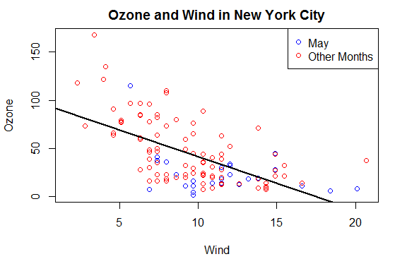

```r
model <- lm(Ozone ~ Wind, airquality)
# regression line is produced here
abline(model, lwd = 2)
```

### Multiple Plot Example

- **Note**: typing `example(points)` in R will launch a demo of base plotting system and may provide some helpful tips on graphing

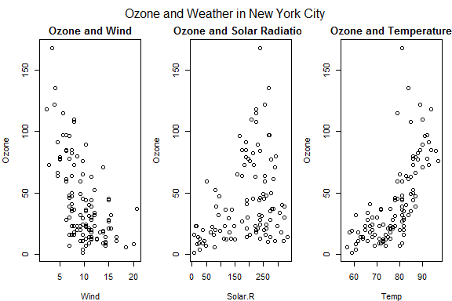

```r
# this expression sets up a plot with 1 row 3 columns, sets the margin and outer margins
par(mfrow = c(1, 3), mar = c(4, 4, 2, 1), oma = c(0, 0, 2, 0))
with(airquality, {
    # here three plots are filled in with their respective titles
    plot(Wind, Ozone, main = "Ozone and Wind")
    plot(Solar.R, Ozone, main = "Ozone and Solar Radiation")
    plot(Temp, Ozone, main = "Ozone and Temperature")
    # this adds a line of text in the outer margin*
    mtext("Ozone and Weather in New York City", outer = TRUE)}
)
```

## Graphics Device

- A graphics device is something where you can make a plot appear
  - **window on screen** (screen device) = quick visualizations and exploratory analysis
  - **pdf** (file device) = plots that may be printed out or incorporated in to document
  - **PNG/JPEG** (file device) = plots that may be printed out or incorporated in to document
  - **scalable vector graphics** (SVG)
- When a plot is created in R, it has to be sent to a graphics device
- **Most common is screen device**
  - `quartz()` on Mac, `windows()` on Windows, `x11()` on Unix/Linux
  - `?Devices` = lists devices found
- **Plot creation**
  - screen device
    - call plot/xplot/qplot $\rightarrow$ plot appears on screen device $\rightarrow$ annotate as necessary $\rightarrow$ use
  - file devices
    - explicitly call graphics device $\rightarrow$ plotting function to make plot (write to file) $\rightarrow$ annotate as necessary $\rightarrow$ explicitly close graphics device with `dev.off()`
- **Graphics File Devices**
  - *Vector Formats* (good for line drawings/plots w/ solid colors, a modest number of points)
    - `pdf`: useful for line type graphics, resizes well, usually portable, not efficient if too many points
    - `svg`: XML based scalable vector graphics, support animation and interactivity, web based
    - `win.metafile`: Windows metafile format
    - `postscript`: older format, resizes well, usually portable, can create encapsulated postscript file, Windows often donât have postscript viewer (postscript = predecessor of PDF)
  - *Bitmap Formats* (good for plots w/ large number of points, natural scenes/webbased plots)
    - `png`: Portable Network Graphics, good for line drawings/image with solid colors, uses lossless compression, most web browsers read this natively, good for plotting a lot of data points, does not resize well
    - `JPEG`: good for photographs/natural scenes/gradient colors, size efficient, uses lossy compression, good for plotting many points, does not resize well, can be read by almost any computer/browser, not great for line drawings (aliasing on edges)
    - `tiff`: common bitmap format supports lossless compression
    - `bmp`: native Windows bitmapped format
- **Multiple Open Graphics Devices**
  - possible to open multiple graphics devices (screen, file, or both)
  - plotting occurs only one device at a time
  - `dev.cur()` = returns the currently active device
  - every open graphics device is assigned an integer >= 2
  - `dev.set(<integer>)` = change the active graphics device `<integer>` = number associated with the graphics device you want to switch to
- **Copying plots**
  - `dev.copy()` = copy a plot from one device to another
  - `dev.copy2pdf()` = specifically for copying to PDF files
  - **Note**: copying a plot is not an exact operation, so the result may not be identical to the original
  - *example*

```r
## Create plot on screen device
with(faithful, plot(eruptions, waiting))
## Add a main title
title(main = "Old Faithful Geyser data")
```

[output not shown]

```r
## Copy my plot to a PNG file
dev.copy(png, file = "geyserplot.png")
## Don't forget to close the PNG device!
dev.off()
```

$\pagebreak$

## `lattice` Plotting System

- `library(lattice)` = load lattice system
- implemented using the `lattice` and `grid` packages
  - `lattice` package = contains code for producing *Trellis* graphics (independent from base graphics system)
  - `grid` package = implements the graphing system; lattice build on top of grid
- all plotting and annotation is done with *single function call*
  - margins/spacing/labels set automatically for entire plot, good for putting multiple on the screen
  - good for conditioning plots $\rightarrow$ examining same plots over different conditions how y changes vs x across different levels of z
  - `panel` functions can be specified/customized to modify the subplots
- lattice graphics functions return an object of class “trellis”, where as base graphics functions plot data directly to graphics device
  - print methods for lattice functions actually plots the data on graphics device
  - trellis objects are auto-printed
  - `trellis.par.set()` $\rightarrow$ can be used to set global graphic parameters for all trellis objects
- hard to annotate, awkward to specify entire plot in one function call
- cannot add to plot once created, panel/subscript functions hard to prepare

### `lattice` Functions and Parameters

- **Funtions**
  - `xyplot()` = main function for creating scatterplots
  - `bwplot()` = box and whiskers plots (box plots)
  - `histogram()` = histograms
  - `stripplot()` = box plot with actual points
  - `dotplot()` = plot dots on “violin strings”
  - `splom()` = scatterplot matrix (like pairs() in base plotting system)
  - `levelplot()`/`contourplot()` = plotting image data
- **Arguments** for `xyplot(y ~ x | f * g, data, layout, panel)`
  - default blue open circles for data points
  - formula notation is used here (`~`) = left hand side is the y-axis variable, and the right hand side is the x-axis variable
  - `f`/`g` = conditioning/categorical variables (optional)
    - basically creates multi-panelled plots (for different factor levels)
    - `*` indicates interaction between two variables
    - intuitively, the xyplot displays a graph between x and y for every level of `f` and `g`
  - `data` = the data frame/list from which the variables should be looked up
    - if nothing is passed, the parent frame is used (searching for variables in the workspace)
    - if no other arguments are passed, defaults will be used
  - `layout` = specifies how the different plots will appear
    - `layout = c(5, 1)` = produces 5 subplots in a horizontal fashion
    - padding/spacing/margin automatically set
  - [optional] `panel` function can be added to control what is plotted inside each panel of the plot
    - `panel` functions receive x/y coordinates of the data points in their panel (along with any additional arguments)
    - `?panel.xyplot` = brings up documentation for the panel functions
    - **Note**: no base plot functions can be used for lattice plots

### `lattice` Example

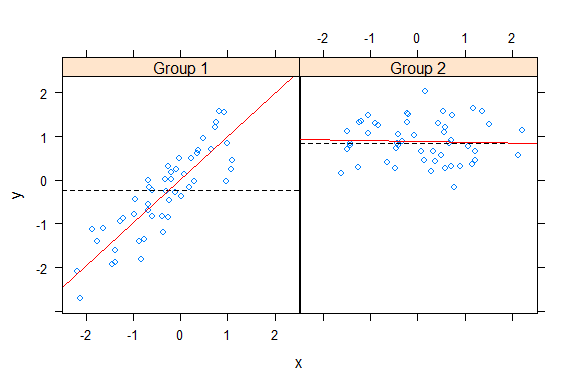

```r
library(lattice)
set.seed(10)
x <- rnorm(100)
f <- rep(0:1, each = 50)
y <- x + f - f * x+ rnorm(100, sd = 0.5)
f <- factor(f, labels = c("Group 1", "Group 2"))
## Plot with 2 panels with custom panel function
xyplot(y ~ x | f, panel = function(x, y, ...) {
    # call the default panel function for xyplot
    panel.xyplot(x, y, ...)
    # adds a horizontal line at the median
    panel.abline(h = median(y), lty = 2)
    # overlays a simple linear regression line
    panel.lmline(x, y, col = 2)
})
```

## `ggplot2` Plotting System

- `library(ggplot2)` = loads ggplot2 package
- implementation of Grammar of Graphics by Leland Wilkinson, written by Hadley Wickham (created RStudio)

> “In brief, the grammar tells us that a statistical graphic is a mapping from data to aesthetic attributes (color, shape, size) of geometric objects (points, lines, bars). The plot may also contain statistical transformations of the data and is drawn on a specific coordinate system”
- grammar graphics plot, splits the different between base and lattice systems
- automatically sets spacings/text/tiles but also allows annotations to be added
- default makes a lot of choices, but still customizable

### `ggplot2` Functions and Parameters

- **basic components** of a `ggplot2` graphic
  - **data frame** = source of data
  - **aesthetic mappings** = how data are mappped to color/size (x vs y)
  - **geoms** = geometric objects like points/lines/shapes to put on page
  - **facets** = conditional plots using factor variables/multiple panels
  - **stats** = statistical transformations like binning/quantiles/smoothing
  - **scales** = scale aesthetic map uses (i.e. male = red, female = blue)
  - **coordinate system** = system in which data are plotted
- `qplot(x, y, data , color, geom)` = quick plot, analogous to base systemâs `plot()` function
  - **default style**: gray background, white gridlines, x and y labels automatic, and solid black circles for data points
  - data always comes from data frame (in unspecified, function will look for data in workspace)
  - plots are made up of aesthetics (size, shape, color) and geoms (points, lines)
  - **Note**: capable of producing quick graphics, but difficult to customize in detail
- **factor variables**: important for graphing subsets of data = they should be labelled with specific information, and not just 1, 2, 3
  - `color = factor1` = use the factor variable to display subsets of data in different colors on the same plot (legend automatically generated)
  - `shape = factor2` = use the factor variable to display subsets of data in different shapes on the same plot (legend automatically generated)
  - *example*

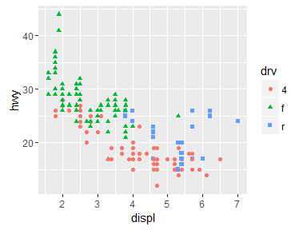

```r
library(ggplot2)
qplot(displ, hwy, data = mpg, color = drv, shape = drv)
```

- **adding statistics**: `geom = c("points", "smooth")` = add a smoother/“low S”
  - “points” plots the data themselves, “smooth” plots a smooth mean line in blue with an area of 95% confidence interval shaded in dark gray
  - `method = "lm"` = additional argument method can be specified to create different lines/confidence intervals
    - `lm` = linear regression
  - *example*

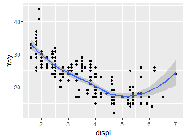

```r
qplot(displ, hwy, data = mpg, geom = c("point", "smooth"))
```

- **histograms**: if only one value is specified, a histogram is produced
  - `fill = factor1` = can be used to fill the histogram with different colors for the subsets (legend automatically generated)
  - *example*

```r
qplot(hwy, data = mpg, fill = drv)
```

[output not shown]

- **facets**: similar to panels in lattice, split data according to factor variables
  - `facets = rows ~ columns` = produce different subplots by factor variables specified (rows/columns)
  - `"."` indicates there are no addition row or column
  - `facets = . ~ columns` = creates 1 by col subplots
  - `facets = row ~ .` = creates row row by 1 subplots
  - labels get generated automatically based on factor variable values
  - *example*

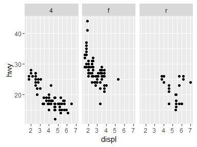

```r
qplot(displ, hwy, data = mpg, facets = . ~ drv)
```

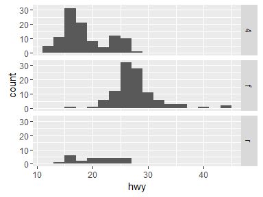

```r
qplot(hwy, data = mpg, facets = drv ~ ., binwidth = 2)
```

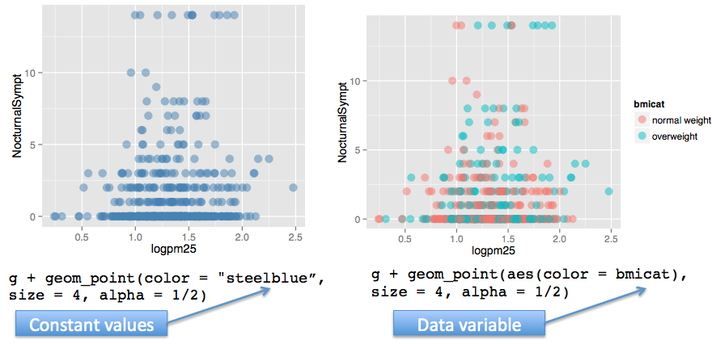

  Alpha Level

  - *axis limits*
    - `+ ylim(-3, 3)` = limits the range of y variable to a specific range
      - **Note**: ggplot will exclude (not plot) points that fall outside of this range (outliers), potentially leaving gaps in plot
    - `+ coord_cartesian(ylim(-3, 3))` = this will limit the visible range but plot all points of the data

### `ggplot2` Comprehensive Example

```r
# initiates ggplot
g <- ggplot(maacs, aes(logpm25, NocturnalSympt))
```

[output not shown]

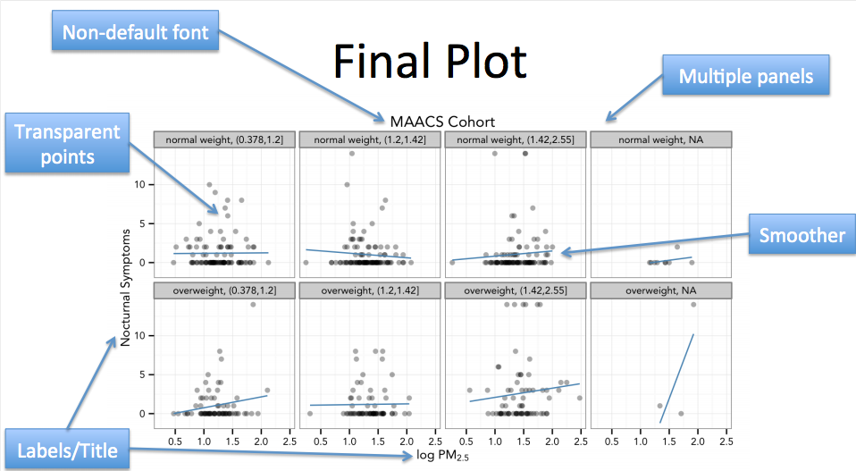

Final Plot

## Hierarchical Clustering

- useful for visualizing high dimensional data, organizes things that are close into groups
- **agglomerative approach** (most common) â bottom up
  1. start with data
  2. find closest pairs, put them together (create “super point” and remove original data)
  3. find the next closest
  4. repeat = yields a tree showing order of merging (dendrogram)
  - requires
    - *merging approach*: how to merge two points
    - *distance metric*: calculating distance between two points
    - **continuous** - *Euclidean distance* $\rightarrow$ $\sqrt{(A_1 - A_2)^2 + (B_1 - B_2)^2 + \dots + (Z_1 -Z_2)^2 }$
    - **continuous** - *correlation similarity* $\rightarrow$ how correlated two data points are
    - **binary** - *Manhattan distance* (“city block distance”) $\rightarrow$ $|A_1 - A_2| + |B_1 - B_2| + \dots + |Z_1 -Z_2|$

[output not shown]

### Procedure for Constructing Hierarchical Clusters (`hclust` function)

1. calculate all pair wise distances between all points to see which points are closest together
   - `dist(data.frame(x=x, y=y)` = returns pair wise distances for all of the (x,y) coordinates
   - **Note**: `dist()` function uses Euclidean distance by default
2. group two closest points from the calculated distances and merge them to a single point
3. find the next two closest points and merge them, and repeat
4. order of clustering is shown in the dendrogram

### Approaches for Merging Points/Clusters

- the approach is specified in the argument `method = "complete"` or `"average"` in `hclust()` function
- *average linkage* = taking average of the x and y coordinates for both points/clusters (center of mass effectively)
- *complete linkage* = to measure distance of two clusters, take the two points in the clusters that are the furthest apart
- **Note**: two approaches may produce different results so itâs a good idea to use both approaches to validate results

### Characteristics of Hierarchical Clustering Algorithms

- clustering result/plot maybe *unstable*
  - changing few points/outliers could lead to large changes
  - change different distance metrics to see how sensitive the clustering is
  - change merging strategy
  - scaling of variables could affect the clustering (if one unit/measurement is much larger than another)
- *deterministic* = running the `hclust` function with same parameters and the same data will produce the same plot
- determining how many clusters there are (where to cut) may *not always be clear*
- *primarily used for exploratory data analysis*, to see over all pattern in data if there is any at all

### `hclust` Function and Example

- `hh <- hclust(dist(dataFrame))` function = produces a hierarchical cluster object based on pair wise distances from a data frame of x and y values
  - `dist()` = defaults to Euclidean, calculates the distance/similarity between two observations; when applied to a data frame, the function applies the $\sqrt{(A_1 - A_2)^2 + (B_1 - B_2)^2 + ... + (Z_1 -Z_2)^2 }$ formula to every pair of rows of data to construct a matrix of distances between the roes
    - order of the hierarchical cluster is derived from the distance
  - `plot(hh)` = plots the dendrogram
  - automatically sorts column and row according to cluster
  - `names(hh)` = returns all parameters of the `hclust` object
    - `hh$order` = returns the order of the rows/clusters from the dendrogram
    - `hh$dist.method` = returns method for calculating distance/similarity
- **Note**: dendrogram that gets generated **DOES NOT** show how many clusters there are, so cutting (at 2.0 level for example) must be done to determine number of clusters â must be a convenient and sensible point
- **`hclust` Example**

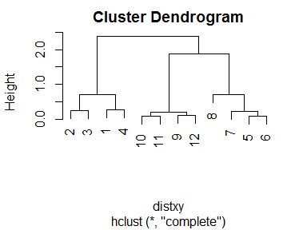

```r
set.seed(1234)
x <- rnorm(12,mean=rep(1:3,each=4),sd=0.2)
y <- rnorm(12,mean=rep(c(1,2,1),each=4),sd=0.2)
dataFrame <- data.frame(x=x,y=y)
distxy <- dist(dataFrame)
hClustering <- hclust(distxy)
plot(hClustering)
```

### `myplcclust` Function and Example

- **Note**: `myplcclust` = a function to plot `hclust` objects in color (clusters labeled 1 2 3 etc.), but must know how many clusters there are initially

```r
myplclust <- function(hclust, lab = hclust$labels,
    lab.col = rep(1, length(hclust$labels)), hang = 0.1, ...) {
    ## modifiction of plclust for plotting hclust objects *in colour*! Copyright
    ## Eva KF Chan 2009 Arguments: hclust: hclust object lab: a character vector
    ## of labels of the leaves of the tree lab.col: colour for the labels;
    ## NA=default device foreground colour hang: as in hclust & plclust Side
    ## effect: A display of hierarchical cluster with coloured leaf labels.
    y <- rep(hclust$height, 2)
    x <- as.numeric(hclust$merge)
    y <- y[which(x < 0)]
    x <- x[which(x < 0)]
    x <- abs(x)
    y <- y[order(x)]
    x <- x[order(x)]
    plot(hclust, labels = FALSE, hang = hang, ...)
    text(x = x, y = y[hclust$order] - (max(hclust$height) * hang), labels = lab[hclust$order],
 col = lab.col[hclust$order], srt = 90, adj = c(1, 0.5), xpd = NA, ...)
}
# example
dataFrame <- data.frame(x = x, y = y)
distxy <- dist(dataFrame)
hClustering <- hclust(distxy)
myplclust(hClustering, lab = rep(1:3, each = 4), lab.col = rep(1:3, each = 4))
```

[output not shown]

### `heatmap` Function and Example

- `heatmap(data.matrix)` function = similar to `image(t(x))`
  - good for visualizing high-dimension matrix data, runs hierarchical analysis on rows and columns of table
  - yellow = high value, red = low value
  - **Note**: the input must be a numeric matrix, so as.matrix(data.frame) can be used to convert if necessary
- *example*

```r
set.seed(12345)
data <- matrix(rnorm(400), nrow = 40)
heatmap(data)
```

[output not shown]

### `image` Function and Example

- `image(x, y, t(dataMatrix)[, nrow(dataMatrix):1])` = produces similar color grid plot as the `heatmap()` without the dendrograms
  - `t(dataMatrix)[, nrow(dataMatrix)]`
    - `t(dataMatrix)` = transpose of dataMatrix, this is such that the plot will be displayed in the same fashion as the matrix (rows as values on the y axis and columns as values on the x axis)
      - *example* 40 x 10 matrix will have graph the 10 columns as x values and 40 rows as y values
    - `[, nrow(dataMatrix)]` = subsets the data frame in reverse column order; when combined with the `t()` function, it reorders the rows of data from 40 to 1, such that the data from the matrix is displayed in order from top to bottom
      - **Note**: without this statement the rows will be displayed in order from bottom to top, as that is in line with the positive y axis
  - `x`, `y` = used to specify the values displayed on the x and y axis
    - **Note**: must be in increasing order
- *example*

```r
image(1:10, 1:40, t(data)[, nrow(data):1])
```

[output not shown]

$\pagebreak$

## K-means Clustering

- similar to hierarchical clustering, focuses on finding things that are close together
  - define close, groups, visualizing/interpreting grouping
- **partitioning approach**
  1. set number of clusters initially
  2. find centroids for each cluster
  3. assign points to the closest centroid
  4. recalculate centroid
  5. repeat = yields estimate of cluster centroids and which cluster each point belongs to
  - **requires**
    - distance metric
    - initial number of clusters
    - initial guess as to where the cluster centroids are

### Procedure for Constructing K-means Clusters (`kmeans` function)

1. choose three random points as the starting centroids
2. take each of the data points and assign it to the closest centroid (creating a cluster around each starting point)
3. take each cluster and recalculate the centroid (taking the mean) with its enclosed data points
4. repeat step 2 and 3 (reassign points to centroids and update centroid locations) until a stable result is achieved
- *example*

```r
set.seed(1234)
x <- rnorm(12,mean=rep(1:3,each=4),sd=0.2)
y <- rnorm(12,mean=rep(c(1,2,1),each=4),sd=0.2)
dataFrame <- data.frame(x=x,y=y)
# specifies initial number of clusters to be 3
kmeansObj <- kmeans(dataFrame,centers=3)
names(kmeansObj)
# returns cluster assignments
kmeansObj$cluster
par(mar=rep(0.2,4))
plot(x,y,col=kmeansObj$cluster,pch=19,cex=2)
points(kmeansObj$centers,col=1:3,pch=3,cex=3,lwd=3)
```

[output not shown]

### Characteristics of K-means Clustering Algorithms

$\pagebreak$

## Dimension Reduction

- two kinds of problems that relate to high-dimension dataset/matrix with many variables
  1. find a new set (smaller) of variables that are uncorrelated and explain as much variance of data as possible
     - normally many variables are not independent (i.e. height vs weight)
     - statistical problem, commonly solved with PCA
  2. find a lower rank matrix (best matrix created with fewer variables) that still explains the data
     - data compression problem, commonly solved SVD
- *example*
  - **Note**: we are arbitrarily introduced pattern in data: we flip a coin and if the it is heads, we replace the row with [0, 0, 0, 0, 0, 3, 3, 3, 3, 3]
  - here we plot the patterns in rows and columns (already sorted)

```r
for(i in 1:40){
  # flip a coin
  coinFlip <- rbinom(1,size=1,prob=0.5)
  # if coin is heads add a common pattern to that row
  if(coinFlip){
    data[i,] <- data[i,] + rep(c(0,3),each=5)
  }
}
# hierarchical clustering
hh <- hclust(dist(data))
dataOrdered <- data[hh$order,]
# create 1 x 3 panel plot
par(mfrow=c(1,3))
# heat map (sorted)
image(t(dataOrdered)[,nrow(dataOrdered):1])
# row means (40 rows)
plot(rowMeans(dataOrdered),40:1,,xlab="Row Mean",ylab="Row",pch=19)
# column means (10 columns)
plot(colMeans(dataOrdered),xlab="Column",ylab="Column Mean",pch=19)
```

[output not shown]

### Singular Value Decomposition (SVD)

- Let $X$ = matrix which each variable in column (measurement) and each observation in row (subject)
- SVD in this case is a **matrix decomposition** process, in which X is divided into *three* separate matrices as follows:
  $$X = UDV^T$$
  - $U$ = left singular vector, orthogonal matrix (columns independent of each other)
  - $D$ = singular values, diagonal matrix
  - $V$ = right singular vector, orthogonal matrix (columns independent of each other)
  - **Note**: orthogonal implies that a matrix is always invertible [$A^{-1} = A^T$] and that the product of the matrix and its transpose equals the identity matrix [$AA^T = I$]
    - when a orthogonal matrices, $A$, is multiplied by another matrix, $B$, it is effectively a linear transformation in that the length and angles of $B$ are preserved
  - **Note**: diagonal implies that any value outside of the main diagonal ($\searrow$) = 0
    - example
      $$A = \begin{bmatrix}
      1 & 0 & 0 \\
      0 & 2 & 0 \\
      0 & 0 & 3 \end{bmatrix}$$
- **Note**: scale of data matters for SVD/PCA (scaling the data may help), patterns detected maybe mixed together, and computation is intensive for these operations

### Principal Components Analysis (PCA)

- first scale the variables and run SVD on normalized matrix
  - **scaling** = subtract each column by its mean and divide by its standard deviation
- **principal components** = the right singular values or the $V$ matrix

### SVD and PCA Example

- **$U$ and $V$ Matrices**
  - `s <- svd(data)` = performs SVD on data ($n \times m$ matrix) and splits it into $u$, $v$, and $d$ matrices
    - `s$u` = $n \times m$ matrix $\rightarrow$ horizontal variation
    - `s$d` = $1 \times m$ vector $\rightarrow$ vector of the singular/diagonal values
      - `diag(s$d)` = $m \times m$ diagonal matrix
    - `s$v` = $m \times m$ matrix $\rightarrow$ vertical variation
    - `s$u %*% diag(s$d) %*% t(s$v)` = returns the original data $\rightarrow$ $X = UDV^T$
  - `scale(data)` = scales the original data by subtracting each data point by its column mean and dividing by its column standard deviation

```r
# running svd
svd1 <- svd(scale(dataOrdered))
# create 1 by 3 panel plot
par(mfrow=c(1,3))
# data heatmap (sorted)
image(t(dataOrdered)[,nrow(dataOrdered):1])
# U Matrix - first column
plot(svd1$u[,1],40:1,,xlab="Row",ylab="First left singular vector",pch=19)
# V vector - first column
plot(svd1$v[,1],xlab="Column",ylab="First right singular vector",pch=19)
```

[output not shown]

```r
# create 1 x 2 panel plot
par(mfrow=c(1,2))
# plot singular values
plot(svd1$d,xlab="Column",ylab="Singular value",pch=19)
# plot proportion of variance explained
plot(svd1$d^2/sum(svd1$d^2),xlab="Column",ylab="Prop. of variance explained",pch=19)
```

[output not shown]

- **Relationship to PCA**
  - `p <- prcomp(data, scale = TRUE)` = performs PCA on data specified
    - `scale = TRUE` = scales the data before performing PCA
    - returns `prcomp` object
    - `summary(p)` = prints out the principal component’s standard deviation, proportion of variance, and cumulative proportion
  - PCA’s rotation vectors are equivalent to their counterparts in the V matrix from the SVD

```r
# SVD
svd1 <- svd(scale(dataOrdered))
# PCA
pca1 <- prcomp(dataOrdered,scale=TRUE)
# Plot the rotation from PCA (Principal Components) vs v vector from SVD
plot(pca1$rotation[,1],svd1$v[,1],pch=19,xlab="Principal Component 1",
    ylab="Right Singular Vector 1")
abline(c(0,1))
# summarize PCA
summary(pca1)
```

[output not shown]

```r
set.seed(678910)
# setting pattern
data <- matrix(rnorm(400), nrow = 40)
for(i in 1:40){
  # flip a coin
  coinFlip1 <- rbinom(1,size=1,prob=0.5)
  coinFlip2 <- rbinom(1,size=1,prob=0.5)
  # if coin is heads add a common pattern to that row
  if(coinFlip1){
    data[i,] <- data[i,] + rep(c(0,5),each=5)
  }
  if(coinFlip2){
    data[i,] <- data[i,] + rep(c(0,5),5)
  }
}
hh <- hclust(dist(data)); dataOrdered <- data[hh$order,]

# perform SVD
svd2 <- svd(scale(dataOrdered))
par(mfrow=c(2,3))
image(t(dataOrdered)[,nrow(dataOrdered):1])
plot(rep(c(0,1),each=5),pch=19,xlab="Column", main="True Pattern 1")
plot(rep(c(0,1),5),pch=19,xlab="Column",main="True Pattern 2")
image(t(dataOrdered)[,nrow(dataOrdered):1])
plot(svd2$v[,1],pch=19,xlab="Column",ylab="First right singular vector",
    main="Detected Pattern 1")
plot(svd2$v[,2],pch=19,xlab="Column",ylab="Second right singular vector",
    main="Detected Pattern 2")
```

[output not shown]

- **Missing Data**
  - SVD cannot be performed on dataset with `NA` values
  - `impute` package from [Bioconductor](http://bioconductor.org) can help approximate missing values from surrounding values
    - `impute.knn` function takes the missing row and imputes the data using the `k` nearest neighbors to that row
      - `k=10` = default value (take the nearest 10 rows)

```r
library(impute)  ## Available from http://bioconductor.org
data2 <- dataOrdered
# set random samples = NA
data2[sample(1:100,size=40,replace=FALSE)] <- NA
data2 <- impute.knn(data2)$data
svd1 <- svd(scale(dataOrdered)); svd2 <- svd(scale(data2))
par(mfrow=c(1,2))
plot(svd1$v[,1],pch=19, main="Original")
plot(svd2$v[,1],pch=19, main="Imputed")
```

[output not shown]

### Create Approximations/Data Compression

```r
# load faceData
load("figures/face.rda")
# perform SVD
svd3 <- svd(scale(faceData))
plot(svd3$d^2/sum(svd3$d^2),pch=19,xlab="Singular vector",ylab="Variance explained")
```

[output not shown]

- approximations can thus be created by taking the first few components and using matrix multiplication with the corresponding $U$, $V$, and $D$ components

```r
approx1 <- svd3$u[,1] %*% t(svd3$v[,1]) * svd3$d[1]
approx5 <- svd3$u[,1:5] %*% diag(svd3$d[1:5])%*% t(svd3$v[,1:5])
approx10 <- svd3$u[,1:10] %*% diag(svd3$d[1:10])%*% t(svd3$v[,1:10])
# create 1 x 4 panel plot
par(mfrow=c(1,4))
# plot original facedata
image(t(approx1)[,nrow(approx1):1], main = "1 Component")
image(t(approx5)[,nrow(approx5):1], main = "5 Component")
image(t(approx10)[,nrow(approx10):1], main = "10 Component")
image(t(faceData)[,nrow(faceData):1], main = "Original")
```

[output not shown]

$\pagebreak$

## Color Packages in R Plots

- proper use of color can help convey the message by improving clarity/contrast of data presented
- default color schemes for most plots in R are fairly terrible, so some external packages are helpful

### `grDevices` Package

- `colors()` function = lists names of colors available in any plotting function
- **`colorRamp` function**
  - takes any set of colors and return a function that takes values between 0 and 1, indicating the extremes of the color palette (e.g. see the `gray` function)
  - `pal <- colorRamp(c("red", "blue"))` = defines a `colorRamp` function
  - `pal(0)` returns a 1 x 3 matrix containing values for RED, GREEN, and BLUE values that range from 0 to 255
  - `pal(seq(0, 1, len = 10))` returns a 10 x 3 matrix of 10 colors that range from RED to BLUE (two ends of spectrum defined in the object)
  - *example*

```r
# define colorRamp function
pal <- colorRamp(c("red", "blue"))
# create a color
pal(0.67)
```

[output not shown]

- **`colorRampPalette` function**
  - takes any set of colors and return a function that takes integer arguments and returns a vector of colors interpolating the palette (like `heat.colors` or `topo.colors`)
  - `pal <- colorRampPalette(c("red", "yellow"))` defines a `colorRampPalette` function
  - `pal(10)` returns 10 interpolated colors in hexadecimal format that range between the defined ends of spectrum
  - *example*

```r
# define colorRampPalette function
pal <- colorRampPalette(c("red", "yellow"))
# create 10 colors
pal(10)
```

[output not shown]

- **`rgb` function**
  - `red`, `green`, and `blue` arguments = values between 0 and 1
  - `alpha = 0.5` = transparency control, values between 0 and 1
  - returns hexadecimal string for color that can be used in `plot`/`image` commands
  - `colorspace` package `cna` be used for different control over colors
  - *example*

```r
x <- rnorm(200); y <- rnorm(200)
par(mfrow=c(1,2))
# normal scatter plot
plot(x, y, pch = 19, main = "Default")
# using transparency shows data much better
plot(x, y, col = rgb(0, 0, 0, 0.2), main = "With Transparency")
```

[output not shown]

### `RColorBrewer` Package

```r
library(RColorBrewer)
# generate 3 colors using brewer.pal function
cols <- brewer.pal(3, "BuGn")
pal <- colorRampPalette(cols)
par(mfrow=c(1,3))
# heat.colors/default
image(volcano, main = "Heat.colors/Default")
# topographical colors
image(volcano, col = topo.colors(20), main = "Topographical Colors")
# RColorBrewer colors
image(volcano, col = pal(20), main = "RColorBrewer Colors")
```

[output not shown]

- **`smoothScatter` function**
  - used to plot large quantities of data points
  - creates 2D histogram of points and plots the histogram
  - default color scheme = “Blues” palette from `RColorBrewer` package
  - *example*

```r
x <- rnorm(10000); y <- rnorm(10000)
smoothScatter(x, y)
```

[output not shown]

$\pagebreak$

## Case Study: Human Activity Tracking with Smart Phones

**Loading Training Set of Samsung S2 Data from [UCI Repository](http://archive.ics.uci.edu/ml/datasets/Human+Activity+Recognition+Using+Smartphones)**

```r
# load data frame provided
load("samsungData.rda")
# table of 6 types of activities
table(samsungData$activity)
```

[output not shown]

**Plotting Average Acceleration for First Subject**

```r
# set up 1 x 2 panel plot
par(mfrow=c(1, 2), mar = c(5, 4, 1, 1))
# converts activity to a factor variable
samsungData <- transform(samsungData, activity = factor(activity))
# find only the subject 1 data
sub1 <- subset(samsungData, subject == 1)
# plot mean body acceleration in X direction
plot(sub1[, 1], col = sub1$activity, ylab = names(sub1)[1],
    main = "Mean Body Acceleration for X")
# plot mean body acceleration in Y direction
plot(sub1[, 2], col = sub1$activity, ylab = names(sub1)[2],
    main = "Mean Body Acceleration for Y")
# add legend
legend("bottomright",legend=unique(sub1$activity),col=unique(sub1$activity), pch = 1)
```

[output not shown]

**Clustering Based on Only Average Acceleration**

```r
# load myplclust function
source("myplclust.R")
# calculate distance matrix
distanceMatrix <- dist(sub1[,1:3])
# form hclust object
hclustering <- hclust(distanceMatrix)
# run myplclust on data
myplclust(hclustering, lab.col = unclass(sub1$activity))
```

[output not shown]

**Plotting Max Acceleration for the First Subject**

```r
# create 1 x 2 panel
par(mfrow=c(1,2))
# plot max accelecrations in x and y direction
plot(sub1[,10],pch=19,col=sub1$activity,ylab=names(sub1)[10],
    main = "Max Body Acceleration for X")
plot(sub1[,11],pch=19,col = sub1$activity,ylab=names(sub1)[11],
    main = "Max Body Acceleration for Y")
```

[output not shown]

**Clustering Based on Maximum Acceleration**

```r
# calculate distance matrix for max distances
distanceMatrix <- dist(sub1[,10:12])
hclustering <- hclust(distanceMatrix)
myplclust(hclustering,lab.col=unclass(sub1$activity))
```

[output not shown]

**Singular Value Decomposition**

```r
# perform SVD minus last two columns (subject and activity)
svd1 = svd(scale(sub1[,-c(562,563)]))
# create 1 x 2 panel plot
par(mfrow=c(1,2))
# plot first two left singular vector
# separate moving from non moving
plot(svd1$u[,1],col=sub1$activity,pch=19, main = "First Left Singular Vector")
plot(svd1$u[,2],col=sub1$activity,pch=19, main = "Second Left Singular Vector")
```

[output not shown]

**New Clustering with Maximum Contributers**

```r
# find the max contributing feature
maxContrib <- which.max(svd1$v[,2])
# recalculate distance matrix
distanceMatrix <- dist(sub1[, c(10:12,maxContrib)])
hclustering <- hclust(distanceMatrix)
myplclust(hclustering,lab.col=unclass(sub1$activity))
# name of max contributing factor
names(samsungData)[maxContrib]
```

[output not shown]

**K-means Clustering (nstart=1, first try)**

```r
# specify 6 centers for data
kClust <- kmeans(sub1[,-c(562,563)],centers=6)
# tabulate 6 clusteres against 6 activity but many clusters contain multiple activities
table(kClust$cluster,sub1$activity)
```

[output not shown]

**K-means clustering (nstart=100, first try)**

```r
# run k-means algorithm 100 times
kClust <- kmeans(sub1[,-c(562,563)],centers=6,nstart=100)
# tabulate results
table(kClust$cluster,sub1$activity)
```

[output not shown]

**K-means clustering (nstart=100, second try)**

```r
# run k-means algorithm 100 times
kClust <- kmeans(sub1[,-c(562,563)],centers=6,nstart=100)
# tabulate results
table(kClust$cluster,sub1$activity)
```

[output not shown]

**Cluster 1 Variable Centers (Laying)**

```r
# plot first 10 centers of k-means for laying to understand which features drive the activity
plot(kClust$center[1,1:10],pch=19,ylab="Cluster Center",xlab="")
```

[output not shown]

```r
# plot first 10 centers of k-means for laying to understand which features drive the activity
plot(kClust$center[4,1:10],pch=19,ylab="Cluster Center",xlab="")
```

[output not shown]

$\pagebreak$

## Case Study: Fine Particle Pollution in the U.S. from 1999 to 2012

**Read Raw Data from 1999 and 2012**

```r
# read in raw data from 1999
pm0 <- read.table("pm25_data/RD_501_88101_1999-0.txt", comment.char = "#", header = FALSE, sep = "|", na.strings = "")
# read in headers/column lables
cnames <- readLines("pm25_data/RD_501_88101_1999-0.txt", 1)
# convert string into vector
cnames <- strsplit(substring(cnames, 3), "|", fixed = TRUE)
# make vector the column names
names(pm0) <- make.names(cnames[[1]])
# we are interested in the pm2.5 readings in the "Sample.Value" column
x0 <- pm0$Sample.Value
# read in the data from 2012
pm1 <- read.table("pm25_data/RD_501_88101_2012-0.txt", comment.char = "#", header = FALSE, sep = "|",
    na.strings = "", nrow = 1304290)
# make vector the column names
names(pm1) <- make.names(cnames[[1]])
# take the 2012 data for pm2.5 readings
x1 <- pm1$Sample.Value
```

**Summaries for Both Periods**

```r
# generate 6 number summaries
summary(x1)
summary(x0)
# calculate % of missing values, Are missing values important here?
data.frame(NA.1990 = mean(is.na(x0)), NA.2012 = mean(is.na(x1)))
```

[output not shown]

**Make a boxplot of both 1999 and 2012**

```r
par(mfrow = c(1,2))
# regular boxplot, data too right skewed
boxplot(x0, x1, main = "Regular Boxplot")
# log boxplot, significant difference in means, but more spread
boxplot(log10(x0), log10(x1), main = "log Boxplot")
```

[output not shown]

**Check for Negative Values in ‘x1’**

```r
# summary again
summary(x1)
# create logical vector for
negative <- x1 < 0
# count number of negatives
sum(negative, na.rm = T)
# calculate percentage of negatives
mean(negative, na.rm = T)
# capture the date data
dates <- pm1$Date
dates <- as.Date(as.character(dates), "%Y%m%d")
# plot the histogram
hist(dates, "month")  ## Check what's going on in months 1--6
```

[output not shown]

**Check Same New York Monitors at 1999 and 2012**

```r
# find unique monitors in New York in 1999
site0 <- unique(subset(pm0, State.Code == 36, c(County.Code, Site.ID)))
# find unique monitors in New York in 2012
site1 <- unique(subset(pm1, State.Code == 36, c(County.Code, Site.ID)))
# combine country codes and siteIDs of the monitors
site0 <- paste(site0[,1], site0[,2], sep = ".")
site1 <- paste(site1[,1], site1[,2], sep = ".")
# find common monitors in both
both <- intersect(site0, site1)
# print common monitors in 1999 and 2012
print(both)
```

[output not shown]

**Find how many observations available at each monitor**

```r
# add columns for combined county/site for the original data
pm0$county.site <- with(pm0, paste(County.Code, Site.ID, sep = "."))
pm1$county.site <- with(pm1, paste(County.Code, Site.ID, sep = "."))
# find subsets where state = NY and county/site = what we found previously
cnt0 <- subset(pm0, State.Code == 36 & county.site %in% both)
cnt1 <- subset(pm1, State.Code == 36 & county.site %in% both)
# split data by the county/size values and count oberservations
sapply(split(cnt0, cnt0$county.site), nrow)
sapply(split(cnt1, cnt1$county.site), nrow)
```

[output not shown]

**Choose Monitor where County = 63 and Side ID = 2008**

```r
# filter data by state/county/siteID
pm1sub <- subset(pm1, State.Code == 36 & County.Code == 63 & Site.ID == 2008)
pm0sub <- subset(pm0, State.Code == 36 & County.Code == 63 & Site.ID == 2008)
# there are 30 observations from 2012, and 122 from 1999
dim(pm1sub)
dim(pm0sub)
```

[output not shown]

**Plot Data for 2012**

```r
# capture the dates of the subset of data
dates1 <- pm1sub$Date
# capture measurements for the subset of data
x1sub <- pm1sub$Sample.Value
# convert dates to appropriate format
dates1 <- as.Date(as.character(dates1), "%Y%m%d")
# plot pm2.5 value vs time
plot(dates1, x1sub, main = "PM2.5 Polution Level in 2012")
```

[output not shown]

**Plot data for 1999**

```r
# capture the dates of the subset of data
dates0 <- pm0sub$Date
# convert dates to appropriate format
dates0 <- as.Date(as.character(dates0), "%Y%m%d")
# capture measurements for the subset of data
x0sub <- pm0sub$Sample.Value
# plot pm2.5 value vs time
plot(dates0, x0sub, main = "PM2.5 Polution Level in 1999")
```

[output not shown]

**Panel Plot for Both Years**

```r
# find max range for data
rng <- range(x0sub, x1sub, na.rm = T)
# create 1 x 2 panel plot
par(mfrow = c(1, 2), mar = c(4, 4, 2, 1))
# plot time series plot for 1999
plot(dates0, x0sub, pch = 20, ylim = rng, main="Pollution in 1999")
# plot the median
abline(h = median(x0sub, na.rm = T))
# plot time series plot for 2012
plot(dates1, x1sub, pch = 20, ylim = rng, main="Pollution in 2012")
# plot the median
abline(h = median(x1sub, na.rm = T))
```

[output not shown]

**Find State-wide Means and Trend**

```r
# divide data by state and find tne mean of pollution level for 1999
mn0 <- with(pm0, tapply(Sample.Value, State.Code, mean, na.rm = T))
# divide data by state and find tne mean of pollution level for 1999
mn1 <- with(pm1, tapply(Sample.Value, State.Code, mean, na.rm = T))
# convert to data frames while preserving state names
d0 <- data.frame(state = names(mn0), mean = mn0)
d1 <- data.frame(state = names(mn1), mean = mn1)
# merge the 1999 and 2012 means by state
mrg <- merge(d0, d1, by = "state")
# dimension of combined data frame
dim(mrg)
# first few lines of data
head(mrg)

# plot the pollution levels data points for 1999
with(mrg, plot(rep(1, 52), mrg[, 2], xlim = c(.8, 2.2), ylim = c(3, 20),
    main = "PM2.5 Pollution Level by State for 1999 & 2012",
    xlab = "", ylab = "State-wide Mean PM"))
# plot the pollution levels data points for 2012
with(mrg, points(rep(2, 52), mrg[, 3]))
# connected the dots
segments(rep(1, 52), mrg[, 2], rep(2, 52), mrg[, 3])
# add 1999 and 2012 labels
axis(1, c(1, 2), c("1999", "2012"))
```

[output not shown]